# Economic and Physical Impact of Weather Events Across America

## Synopsis

The National Weather Service Storm data is read and analyzed in order to determine the types of storm events that are the most harmful to population health as well as the highest economic consequences. The data shows that the biggest source of property damage in the United States comes from Tornados and is followed by Floods and Flash Flood sources. The highest contributor to crop damage in the United States comes from hail and is followed by flood and flash floods. The highest source of injuries and fatalities from weather events both come from tornados. The second highest fatality source comes from flood sources and is followed by lightning then wind. The second largest source of injuries comes from wind followed by lightning sources.

## Data Processing

The following is the reading and initialization of the dataset:

```r
    #Read and initialize library and data
    library(ggplot2)
    library(grid)
    library(gridExtra)
    library('dplyr')
    library('data.table')
    #Cache and reads data if available
    data = read.csv('repdata_data_StormData.csv', stringsAsFactors=FALSE)
    #Subsets all relevant data for usage
    p2 <<- data.frame(data$STATE,data$EVTYPE,data$INJURIES,data$FATALITIES, data$PROPDMG,data$CROPDMG)
    names(p2) = c('STATE', 'EVTYPE', 'INJURIES', 'FATALITIES', 'PROPDMG', 'CROPDMG')
    p2 = data.table(p2)
```

The following is the cleaning of the data into clean and tidy datasets. The data is first subset into values for the 50 states of the US. Afterwards, as commented in the code below, the EVTYPE variables are cleaned up to correct spelling errors, and to combine similar variables into a single variable.

```r
    #Begin cleaning up the data
    states = c('AL','AK','AZ','AR','CA','CO','CT','DE','FL','GA','HI','ID','IL','IN','IA','KS','KY','LA','ME','MD','MA','MI','MN','MS','MO','MT','NE','NV','NH','NJ','NM','NY','NC','ND','OH','OK','OR','PA','RI','SC','SD','TN','TX','UT','VT','VA','WA','WV','WI','WY')
    test = filter(p2, STATE == states) #filters out other states although leaves factors which is unwanted
```

```r
    test2 = grep('summary',test$EVTYPE,ignore.case=TRUE) #done here to filter out the summary in evtype
    test = test[!test2] #need to remove factors again here

    #Standarizes wind conditions into a single variable
    test$EVTYPE = gsub('HIGH WIND', 'WIND', test$EVTYPE) #Standarize high wind to wind
    test$EVTYPE = gsub('HIGH WINDSS', 'WIND', test$EVTYPE) #Standarize highwindss to wind
    test$EVTYPE = gsub('WINDS', 'WIND', test$EVTYPE) #Standarize winds to wind
    test$EVTYPE = gsub('WIND 73', 'WIND', test$EVTYPE) #Standarize wind 72 to wind
    test$EVTYPE = gsub('TSTM WIND', 'WIND', test$EVTYPE)
    test$EVTYPE = gsub('WIND DAMAGE', 'WIND', test$EVTYPE)
    test$EVTYPE = gsub('DRY MICROBURST WIND', 'WIND', test$EVTYPE)
    test$EVTYPE = gsub('WIND/HAIL', 'WIND', test$EVTYPE)
    test$EVTYPE = gsub('STRONG WIND', 'WIND', test$EVTYPE)
    test$EVTYPE = gsub('EXTREME WINDCHILL', 'WIND', test$EVTYPE)

    #Standarizes thunderstorm elements into one variable
    test$EVTYPE = gsub('THUNDERSTORMS WIND', 'THUNDERSTORM WINDS', test$EVTYPE)
    test$EVTYPE = gsub('THUNDERSTORM WINDS', 'THUNDERSTORM', test$EVTYPE)
    test$EVTYPE = gsub("THUNDERSTORM WIND HAIL", 'THUNDERSTORM', test$EVTYPE)
    test$EVTYPE = gsub("THUNDERSTORM WIND", 'THUNDERSTORM', test$EVTYPE)
    test$EVTYPE = gsub("THUNDERSTORM WIND/LIGHTNING" , 'THUNDERSTORM', test$EVTYPE)
    test$EVTYPE = gsub("THUNDERSTORM/LIGHTNING", 'THUNDERSTORM', test$EVTYPE)
    test$EVTYPE = gsub("THUNDERSTORMLIGHTNING", 'THUNDERSTORM', test$EVTYPE)


    #Standarizes astronomical tides into a single varaible
    test$EVTYPE = gsub("ASTRONOMICAL HIGH TIDE", 'ASTRONOMICAL TIDE LEVELS', test$EVTYPE)
    test$EVTYPE = gsub("ASTRONOMICAL LOW TIDE", 'ASTRONOMICAL TIDE LEVELS', test$EVTYPE)

    #Standarizes coastal flooding
    test$EVTYPE = gsub('Coastal Flood', 'COASTAL FLOODING', test$EVTYPE)
    test$EVTYPE = gsub('COASTAL FLOODINGing', 'COASTAL FLOODING', test$EVTYPE)
    test$EVTYPE = gsub('COASTAL FLOOD', 'COASTAL FLOODING', test$EVTYPE)
    test$EVTYPE = gsub("COASTAL FLOODINGING", 'COASTAL FLOODING',test$EVTYPE)
    test$EVTYPE = gsub('CSTL FLOODING/EROSION', 'COASTAL FLOODING', test$EVTYPE)

    #Standarizes winter weather conditions
    test$EVTYPE = gsub('WINTER STORM', 'WINTER WEATHER', test$EVTYPE)
    test$EVTYPE = gsub('WINTER WEATHER/MIX', 'WINTER WEATHER', test$EVTYPE)
    test$EVTYPE = gsub('WINTRY MIX', 'WINTER WEATHER', test$EVTYPE)

    #Standarizes wild/forest fires
    test$EVTYPE = gsub('WILDFIRES', 'WILD/FOREST FIRE', test$EVTYPE)
    test$EVTYPE = gsub('WILDFIRE', 'WILD/FOREST FIRE', test$EVTYPE)
    test$EVTYPE = gsub('WILD FIRES', 'WILD/FOREST FIRE', test$EVTYPE)

    #Standarizes urban flooding
    test$EVTYPE = gsub('URBAN FLOODING', 'URBAN FLOOD', test$EVTYPE)
    test$EVTYPE = gsub('URBAN/SML STREAM FLD', 'URBAN FLOOD', test$EVTYPE)
    test$EVTYPE = gsub('URBAN FLOOD', 'URBAN FLOODING', test$EVTYPE)

    #Standarizes unseasonable weather
    test$EVTYPE = gsub('UNSEASONABLY WARM', 'UNSEASONABLE TEMP', test$EVTYPE)
    test$EVTYPE = gsub('UNSEASONABLY WET', 'UNSEASONABLE TEMP', test$EVTYPE)

    #Standarizes snow
    test$EVTYPE = gsub('SNOW AND ICE', 'SNOW', test$EVTYPE)
    test$EVTYPE = gsub('SNOW/BLOWING SNOW', 'SNOW', test$EVTYPE)
    test$EVTYPE = gsub('LIGHT SNOW', 'SNOW', test$EVTYPE)
    test$EVTYPE = gsub('Light Snow', 'SNOW', test$EVTYPE)
    test$EVTYPE = gsub('HEAVY SNOW', 'SNOW', test$EVTYPE)
    test$EVTYPE = gsub('HEAVY SNOW/SQUALLS', 'SNOW', test$EVTYPE)
    test$EVTYPE = gsub('HEAVY WET SNOW', 'SNOW', test$EVTYPE)
    test$EVTYPE = gsub('HEAVY LAKE SNOW', 'SNOW', test$EVTYPE)
    test$EVTYPE = gsub('LAKE-EFFECT SNOW', 'SNOW', test$EVTYPE)
    test$EVTYPE = gsub('BLOWING SNOW- EXTREME WIND CHI', 'SNOW', test$EVTYPE)
    test$EVTYPE = gsub('MODERATE SNOWFALL', 'SNOW', test$EVTYPE)
    test$EVTYPE = gsub('SNOW/SQUALLS', 'SNOW', test$EVTYPE)

    #Standardizes dry conditions
    test$EVTYPE = gsub('DRY MICROBURST', 'DRY CONDITIONS', test$EVTYPE)
    test$EVTYPE = gsub('DROUGHT', 'DRY CONDITIONS', test$EVTYPE)

    #Standarize cold temperatures
    test$EVTYPE = gsub('Cold', 'COLD TEMPERATURES', test$EVTYPE)
    test$EVTYPE = gsub('COLD/WIND CHILL', 'COLD TEMPERATURES', test$EVTYPE)
    test$EVTYPE = gsub('EXTREME COLD TEMPERATURES', 'COLD TEMPERATURES', test$EVTYPE)
    test$EVTYPE = gsub('EXTREME COLD', 'COLD TEMPERATURES', test$EVTYPE)

    #Standarize flood
    test$EVTYPE[test$EVTYPE == 'FLOOD'] = 'FLOOD/FLASH FLOOD'
    test$EVTYPE = gsub('FLASH FLOODING', 'FLOOD/FLASH FLOOD', test$EVTYPE)
    test$EVTYPE[test$EVTYPE == 'FLASH FLOOD'] = 'FLOOD/FLASH FLOOD'

    #Standardize freezing conditions
    test$EVTYPE = gsub('FREEZE', 'FREEZING CONDITIONS', test$EVTYPE)
    test$EVTYPE = gsub('FREEZING DRIZZLE', 'FREEZING CONDITIONS', test$EVTYPE)
    test$EVTYPE = gsub('FREEZING FOG', 'FREEZING CONDITIONS', test$EVTYPE)
    test$EVTYPE = gsub('FREEZING RAIN', 'FREEZING CONDITIONS', test$EVTYPE)
    test$EVTYPE = gsub('FREEZING RAIN AND SLEET', 'FREEZING CONDITIONS', test$EVTYPE)
    test$EVTYPE = gsub('FROST/FREEZE', 'FREEZING CONDITIONS', test$EVTYPE)
    test$EVTYPE = gsub('FREEZING CONDITIONS AND SLEET', 'FREEZING CONDITIONS', test$EVTYPE)
    test$EVTYPE = gsub('FROST/FREEZING CONDITIONS', 'FREEZING CONDITIONS', test$EVTYPE)

    #Standarizes hail
    test$EVTYPE[test$EVTYPE == 'HAIL 75'] = 'HAIL'
    test$EVTYPE[test$EVTYPE == 'NON SEVERE HAIL'] = 'HAIL'

    #Standardize surf
    test$EVTYPE[test$EVTYPE == 'HEAVY SURF/HIGH SURF'] = 'HEAVY SURF'
    test$EVTYPE[test$EVTYPE == 'HIGH SURF'] = 'HEAVY SURF'

    #Standard rain
    test$EVTYPE[test$EVTYPE == 'Heavy rain'] = 'HEAVY RAIN'
    test$EVTYPE[test$EVTYPE == 'EXCESSIVE RAINFALL'] = 'HEAVY RAIN'

    #Standarize heat
    test$EVTYPE[test$EVTYPE == 'EXCESSIVE HEAT'] = 'HIGH HEAT'
    test$EVTYPE[test$EVTYPE == 'EXTREME HEAT'] = 'HIGH HEAT'
    test$EVTYPE[test$EVTYPE == 'HEAT'] = 'HIGH HEAT'
    test$EVTYPE[test$EVTYPE == 'RECORD HEAT'] = 'HIGH HEAT'
    test$EVTYPE[test$EVTYPE == 'RECORD WARMTH'] = 'HIGH HEAT'
    test$EVTYPE[test$EVTYPE == 'Temperature record'] = 'HIGH HEAT'

    #Standarizes variables
    test$EVTYPE = gsub('TORNADO F0', 'TORNADO', test$EVTYPE)
    test$EVTYPE = gsub('FUNNEL CLOUDS', 'FUNNEL CLOUD', test$EVTYPE)
    test$EVTYPE = gsub(' LIGHTNING', 'LIGHTNING', test$EVTYPE) #Fix the spaced lightning
    test$EVTYPE = gsub('WATER SPOUT', 'WATERSPOUT', test$EVTYPE)
    test$EVTYPE = gsub("THUNDERSTORMLIGHTNING", 'THUNDERSTORM', test$EVTYPE)
    test$EVTYPE = gsub('TROPICAL DEPRESSION', 'TROPICAL STORM', test$EVTYPE)
    test$EVTYPE = gsub('STORM SURGE/TIDE', 'STORM SURGE', test$EVTYPE)
    test$EVTYPE = gsub('Mudslide', 'MUD SLIDES', test$EVTYPE)
    test$EVTYPE[test$EVTYPE == 'RIP CURRENT'] = 'RIP CURRENTS'
```

From the tidy data set, the data for injuries, fatalities, crop damage, and property damage are compiled in a new table to reflect the sum of their values

```r
    #Creates a new data frame containing the compiled sum of injury/fatality/dmg
    Evtype = unique(test$EVTYPE)
    Injury = numeric()
    Fatality = numeric()
    Cropdmg = numeric()
    Propdmg = numeric()
    for(i in 1:42){
        Injury[i] = sum(test$INJURIES[test$EVTYPE == Evtype[i]])
        Fatality[i] = sum(test$FATALITIES[test$EVTYPE == Evtype[i]])
        Cropdmg[i] = sum(test$CROPDMG[test$EVTYPE == Evtype[i]])
        Propdmg[i] = sum(test$PROPDMG[test$EVTYPE == Evtype[i]])
    }

    results = data.frame(Evtype, Injury, Fatality, Propdmg, Cropdmg)
```

The data is further subset into the highest 6 values of EVTYPE for injuries, fatalities,property damage, and crop damage

```r
    #Subsets out the top 6 values for injuries, fatalities, propdmg, and cropdmg
    highInjury = sort.list(results$Injury, decreasing=TRUE)
    InEV = character()
    Injuries = numeric()

    highFatal = sort.list(results$Fatality, decreasing=TRUE)
    FaEV = character()
    Fatalities = numeric()

    highProp = sort.list(results$Propdmg, decreasing=TRUE)
    PrEV = character()
    PropDMG = numeric()

    highCrop = sort.list(results$Cropdmg, decreasing=TRUE)
    CrEV = character()
    CropDMG = numeric()

    for(i in 1:6){
        InEV[i] = as.character(results$Evtype[highInjury[i]])
        FaEV[i] = as.character(results$Evtype[highFatal[i]])
        PrEV[i] = as.character(results$Evtype[highProp[i]])
        CrEV[i] = as.character(results$Evtype[highCrop[i]])

        Injuries[i] = results$Injury[highInjury[i]]
        Fatalities[i] = results$Fatality[highFatal[i]]
        PropDMG[i] = results$Propdmg[highProp[i]]
        CropDMG[i] = results$Cropdmg[highCrop[i]]
    }

    TopInjury = data.frame(factor(InEV), Injuries)
    TopFatal = data.frame(factor(FaEV), Fatalities)
    TopProp = data.frame(factor(PrEV), PropDMG)
    TopCrop = data.frame(factor(CrEV), CropDMG)

    names(TopInjury) = c('EVTYPE', 'Injuries')
    names(TopFatal) = c('EVTYPE', 'Fatalities')
    names(TopProp) = c('EVTYPE', 'PropDMG')
    names(TopCrop) = c('EVTYPE', 'CropDMG')
```

The data is then plotted in order to help determine highest values of damage caused by the environment

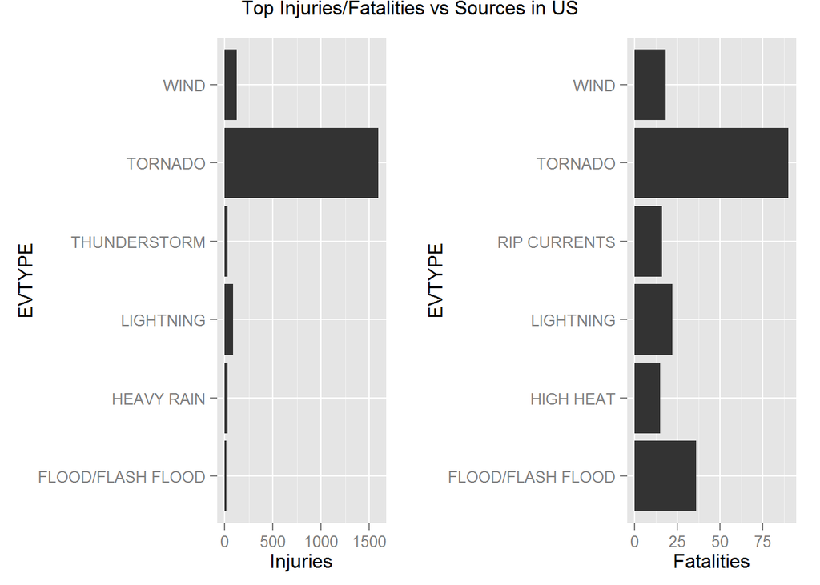

```r
    #Creates plots of the data
    cropPlot = qplot(EVTYPE, CropDMG, data=TopCrop, geom='bar', stat='identity') + coord_flip()
    propPlot = qplot(EVTYPE, PropDMG, data=TopProp, geom='bar', stat='identity') + coord_flip()
    fatalPlot = qplot(EVTYPE, Fatalities, data=TopFatal, geom='bar', stat='identity') + coord_flip()
    injuryPlot = qplot(EVTYPE, Injuries, data=TopInjury, geom='bar', stat='identity') + coord_flip()

    fig1 = grid.arrange(injuryPlot,fatalPlot, ncol=2, main="Top Injuries/Fatalities vs Sources in US")
```

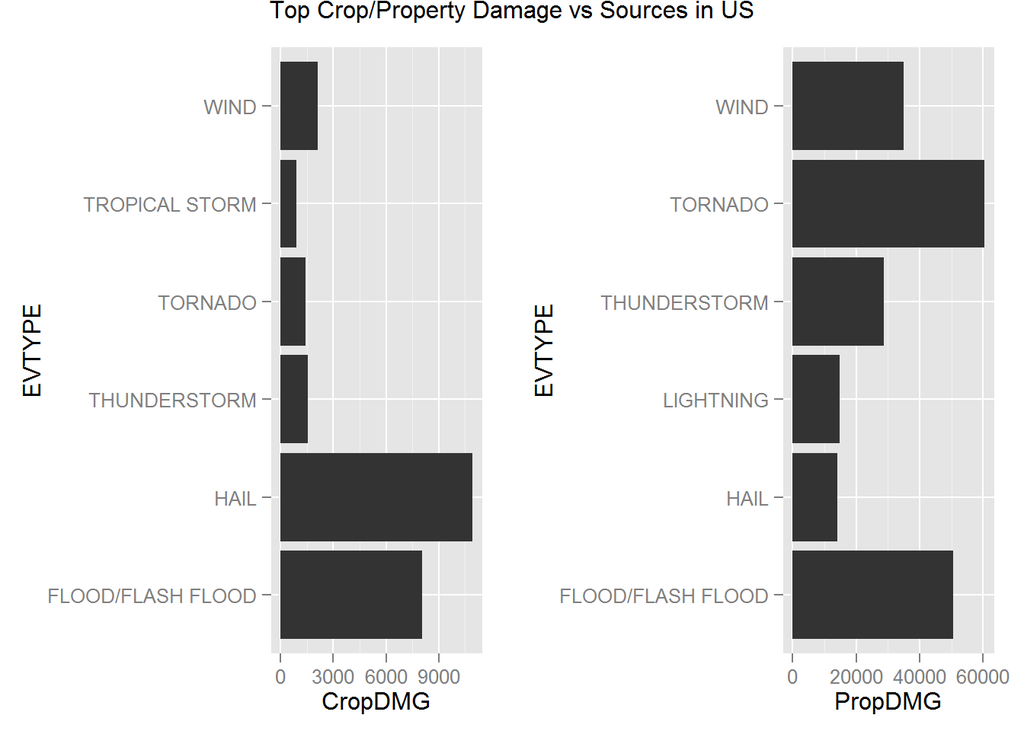

```r
    fig2 = grid.arrange(cropPlot,propPlot, ncol=2, main="Top Crop/Property Damage vs Sources in US")
```

## Results

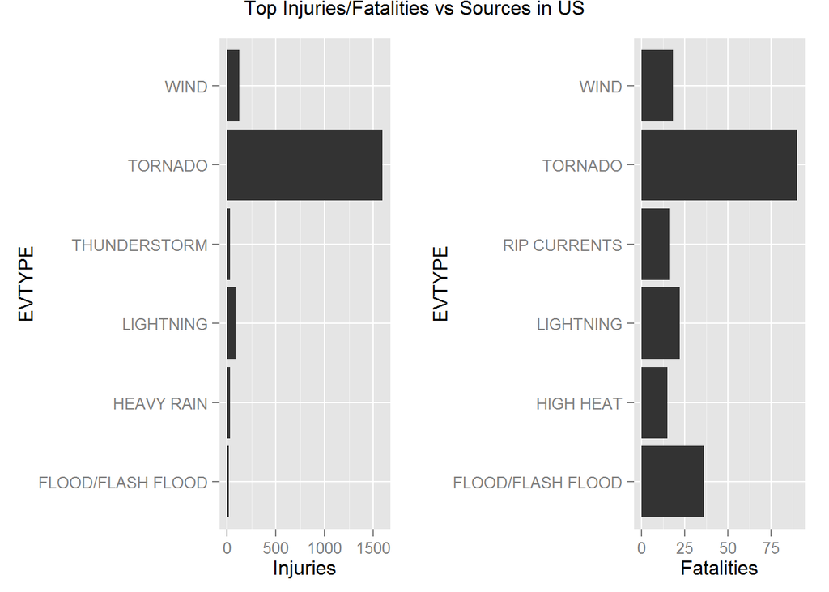

The plot shows the top 6 types of events that cause the highest fatalities and injuries. In both cases, the highest source is tornados. Wind is the second highest followed by lightning for top injuries. The second highest fatality source is floods and flash floods followed by lightining, wind, and rip currents.

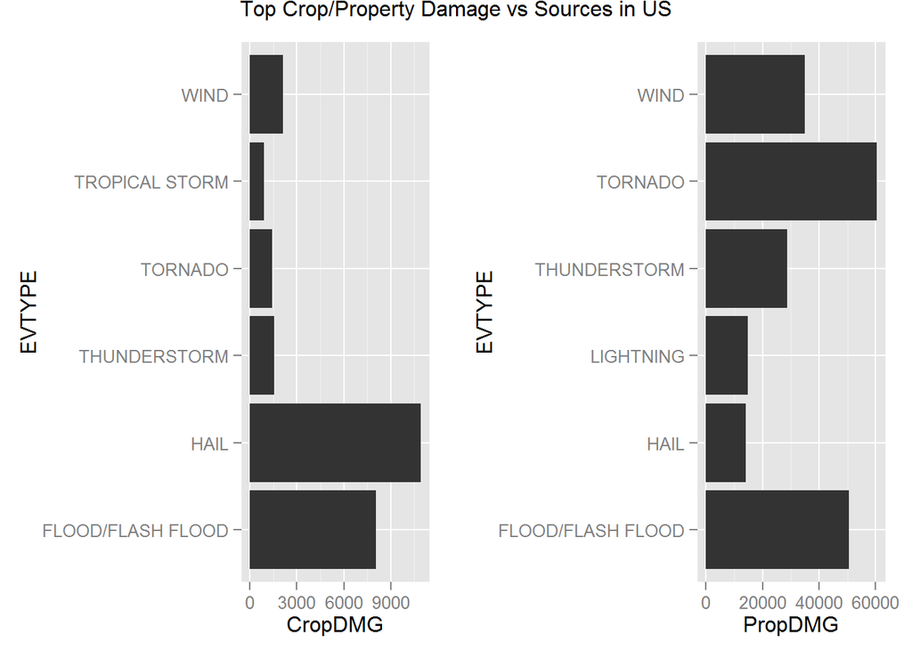

The plot shows the top 6 types of events that cause the highest property and crop damage in the United States. Tornados the largest source of property damage in the United States. Following tornados, floods and flash floods are the second followed by wind and thunderstorms. The highest contributor to crop damage in the United States comes from hail. The second highest comes from flood and flash floods and is followed by wind and thurderstorms.